### Sentences spoken with different emotions

The dataset consists of 1176 short sentences, each spoken with emotion by a young adult female ([ref](https://tspace.library.utoronto.ca/handle/1807/24487)). There is an equal number of sentences for each of 7 emotions: anger, disgust, fear, happy, neutral, pleasant surprise, and sad. The words in sentences are also identical across emotions. Each sentence has seven acoustic characteristics: sentence duration, F0 mean, F0 SD, F0 slope, spectral center-of-gravity, intensity mean, and intensity SD.

[figure not shown]

### How emotions vary on each characteristic

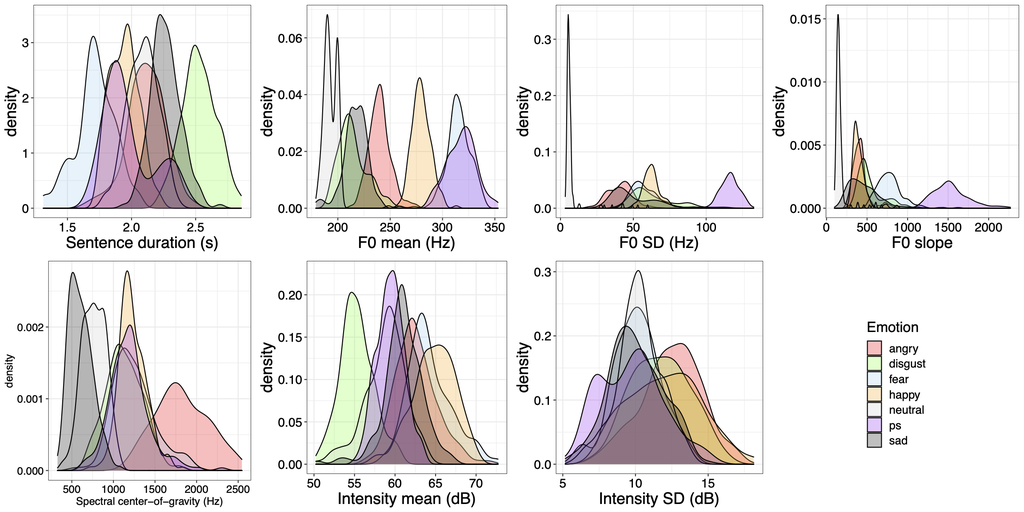

[figure not shown]

##### Table 1. *F* tests: Between-emotion variation relative to within-emotion variation

| Predictor | *F* value |
| --- | --- |
| Sentence duration | 539.66 |
| F0 mean | 3463.9 |
| F0 SD | 1568.7 |
| F0 slope | 1389.2 |
| Spectral CoG | 521.22 |
| Intensity mean | 333.24 |
| Intensity SD | 55.174 |

[figure not shown]

### How do characteristics correlate?

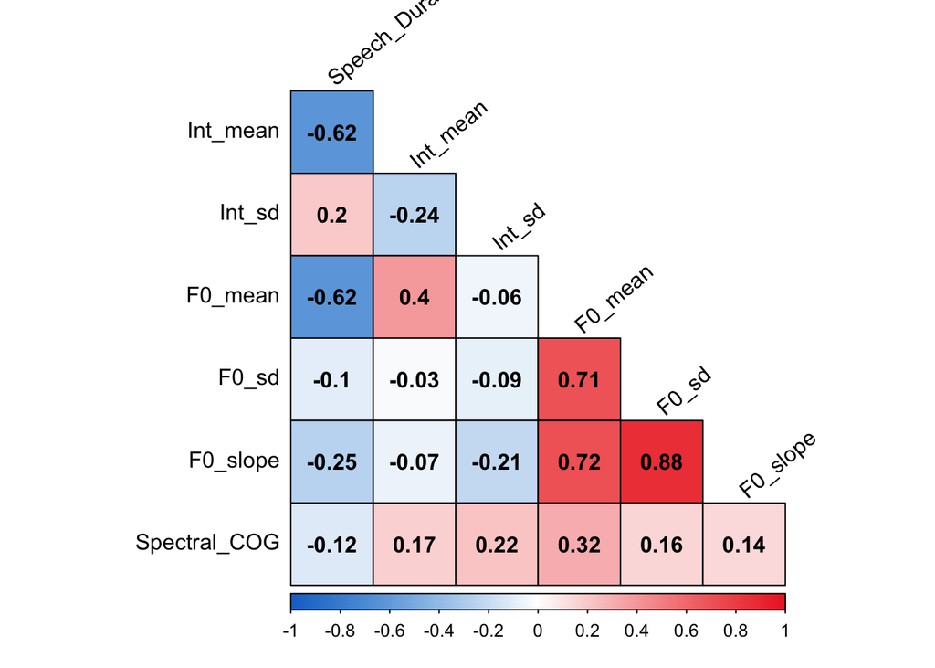

[figure not shown]

### Linear discriminant analysis: Which acoustic characteristics best distinguish emotions?

The dataset of 1176 sentences is split into a training set (n=882) and a test set (n=294); both sets have equal numbers of each emotion.

Using the two predictors with the largest F values, the biggest loss of accuracy comes from a mix-up between Disgust and Sad sentences.

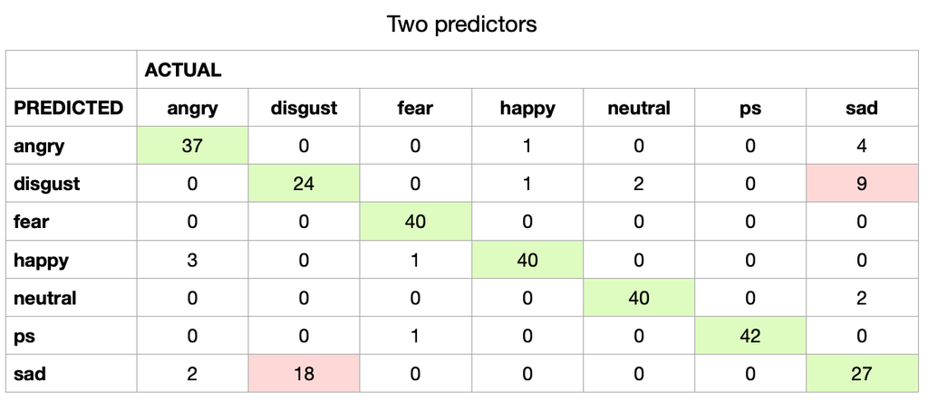

[figure not shown]

##### Table 2. *t* tests: Differences between Disgust and Sad

| Predictor | *t* values |
| --- | --- |
| Sentence duration | 19.189 |
| F0 mean | -1.5012 |
| F0 SD | 8.047 |
| F0 slope | 4.718 |
| Spectral CoG | 26.101 |
| Intensity mean | -23.455 |
| Intensity SD | 8.1817 |

[figure not shown]

Adding a third acoustic predictor that best distinguishes Disgust and Sad sentences (Spectral CoG), model accuracy increases by almost 10 percentage points for the test set, and is within 3 points of a model with all predictors. Adding predictors beyond 3 does not lead to any significant improvement in model performance (95% confidence intervals shown in blue).

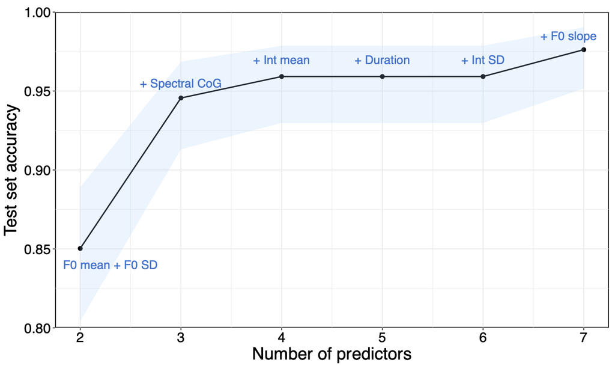

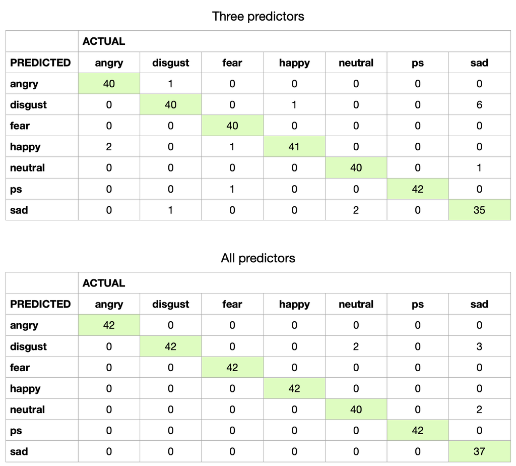